# Breast Cancer Dataset Analysis

Tianqi Li

2025-05-01

# Introduction

Breast cancer is a condition characterized by the uncontrolled growth of cells in the breast, leading to the formation of a tumor, which may be benign (non-cancerous) or malignant (cancerous). As reported by the WHO (2024), it has emerged as the most prevalent cancer among women in 157 out of 185 countries, resulting in 670,000 deaths globally in 2022.

Therefore, identifying the hallmark characteristics of malignant tumors is crucial. Gaining this understanding will improve our ability to differentiate between benign (non-cancerous) and malignant (cancerous) tumors, enabling earlier diagnosis and timely treatment.

This dataset contains 31 variable of tumor feature in breast, including tumor radius, texture, perimeter, smoothness ect.. It can be applied to classify tumors into malignant (cancerous) or benign(non-cancerous). In this dataset of 31 variables, we will exclude those that are similar or biologically irrelevant to prevent overfitting in subsequent analyses.

## Analysis objectives

1. Identify the key features that differentiate malignant tumors from benign ones.
2. Analyze the distribution of tumor characteristics variables between malignant and benign tumors.
3. Construct models in predicting the diagnosis of a tumor.

# Descriptive Analysis

## Tabular analysis

Prior to conducting the data analysis, it is essential to obtain an overview of the dataset, as this will enable a deeper understanding of its structure and facilitate a more thorough analysis.

This table offers first 5 rows of our interested variable.

First 5 rows of data

| diagnosis | radius_mean | texture_mean | perimeter_worst | concave.points_worst | area_worst |
| --- | --- | --- | --- | --- | --- |
| M | 17.99 | 10.38 | 184.60 | 0.2654 | 2019.0 |
| M | 20.57 | 17.77 | 158.80 | 0.1860 | 1956.0 |
| M | 19.69 | 21.25 | 152.50 | 0.2430 | 1709.0 |
| M | 11.42 | 20.38 | 98.87 | 0.2575 | 567.7 |
| M | 20.29 | 14.34 | 152.20 | 0.1625 | 1575.0 |

Characteristics of the 569 patients with breast cancer are displayed in the table below.

| **Characteristic** | **Overall** N = 569<sup>1</sup> | **B** N = 357<sup>1</sup> | **M** N = 212<sup>1</sup> | **p-value**<sup>2</sup> |
| --- | --- | --- | --- | --- |
| Worst value of the concave points | 0.10 (0.06, 0.16) | 0.07 (0.05, 0.10) | 0.18 (0.15, 0.21) | <0.001 |
| Largest perimeter | 98 (84, 125) | 87 (78, 97) | 138 (119, 160) | <0.001 |
| texture mean | 18.8 (16.2, 21.8) | 17.4 (15.2, 19.8) | 21.5 (19.3, 23.8) | <0.001 |
| largest tumor area | 687 (515, 1,084) | 547 (447, 670) | 1,303 (969, 1,717) | <0.001 |

<sup>1</sup> Median (Q1, Q3)  
<sup>2</sup> Wilcoxon rank sum test

This table presents the distribution of various tumor characteristics across three groups: Overall (N = 569), Benign tumors (N = 357), and Malignant tumors (N = 212). The values are presented as median (Q1, Q3), representing the median and the first and third quartiles, along with the p-value to test statistical significance.

Overall, all four tumor characteristics (worst value of the concave points, largest perimeter, texture mean, and largest tumor area) show statistically significant differences between benign and malignant tumors, with malignant tumors exhibiting higher values in all cases (The median value of malignant group is 0.18, 138, 21.5, 1303, however, the corresponding value of benign group is 0.07, 87, 17.4, 547).

## Graphical analysis

In this section, histograms were generated to visualize the data, which also contributes to analyze the distribution of tumor characteristic variables between malignant and benign tumors. Furthermore, these histograms serve as a valuable tool for identifying potential outliers within the dataset.

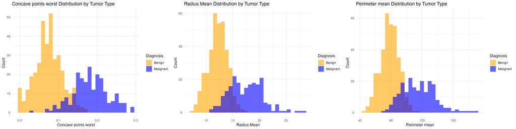

The data in the benign group roughly follows normal distribution. In contrast, the malignant group displays notable differences. Specifically, for the figures of Radius Mean and Perimeter Mean, although the tails resemble those of a normal distribution, the lack of a distinct central peak indicates a departure from normality.

# Regression Analysis

## Logistic regression model

Logistic Regression, a well-established statistical model for binary classification tasks, is commonly used due to its efficiency and accuracy. It is ideal as a baseline model for assessing performance. In this analysis, the outcome is binary, with a value of 1 representing a malignant tumor and 0 representing a benign tumor.

| **Characteristic** | **OR** | **95% CI** | **p-value** |
| --- | --- | --- | --- |
| Radius mean | 0.10 | 0.04, 0.22 | <0.001 |
| Largest perimeter | 1.33 | 1.18, 1.51 | <0.001 |
| texture mean | 1.35 | 1.21, 1.53 | <0.001 |
| largest tumor area | 1.01 | 1.00, 1.02 | 0.008 |

Abbreviations: CI = Confidence Interval, OR = Odds Ratio

This table demonstrates the Odds Ratios (OR), 95% Confidence Intervals (CI), and p-values for various tumor characteristics, assessing their association with tumor malignancy.